# Homework 1

JR Chansakul

2020-09-14

```r
library(tidyverse)
```

# Problem 1

Created a data frame with specified elements.

```r
problem1_df =
  tibble(
    samp = rnorm(10),
    samp_gt_0 = samp > 0,
    char_vec = c("a", "b", "c", "d", "e", "f", "g", "h", "i", "j"),
    factor_vec = factor(c("low", "low", "low", "mod", "mod", "mod", "mod", "high", "high", "high"))
  )
```

Take the mean of each variable in the data frame:

```r
mean (pull(problem1_df, samp))
## [1] 0.427448
mean (pull(problem1_df, samp_gt_0))
## [1] 0.7
mean (pull(problem1_df, char_vec))
## Warning in mean.default(pull(problem1_df, char_vec)): argument is not numeric or
## logical: returning NA
## [1] NA
mean (pull(problem1_df, factor_vec))
## Warning in mean.default(pull(problem1_df, factor_vec)): argument is not numeric
## or logical: returning NA
## [1] NA
```

The mean works for sample and logical vectors, but not character vectors and factor vectors.

```r
as.numeric (pull(problem1_df, samp))
as.numeric (pull(problem1_df, samp_gt_0))
as.numeric (pull(problem1_df, char_vec))
as.numeric (pull(problem1_df, factor_vec))
```

# Problem 2

```r
data("penguins", package = "palmerpenguins")
```

The Penguin dataset contains the following variables: bill_depth_mm, bill_length_mm, body_mass_g, flipper_length_mm, island, sex, species, year

The size of the Penguin dataset contains 344 rows or observations and 8 columns or variables.

Species is factor variable with 3 categories: Adelie, Chinstrap, Gentoo.

Island is factor variable with with 3 categories: Biscoe, Dream, Torgersen.

Flipper length is a integer variable. The mean flipper length is 200.9152047mm and the median flipper length is 197mm. The range for flipper length is between 172, 231mm.

Body mass is a integer variable with a mean of 4201.754386 grams from the sample.

Sex is factor variable with these categories: female, male.

Year is integer variable with a range of 2007, 2009.

This is the code Scatterplot of flipper_length_mm (y) vs bill_length_mm (x) below:

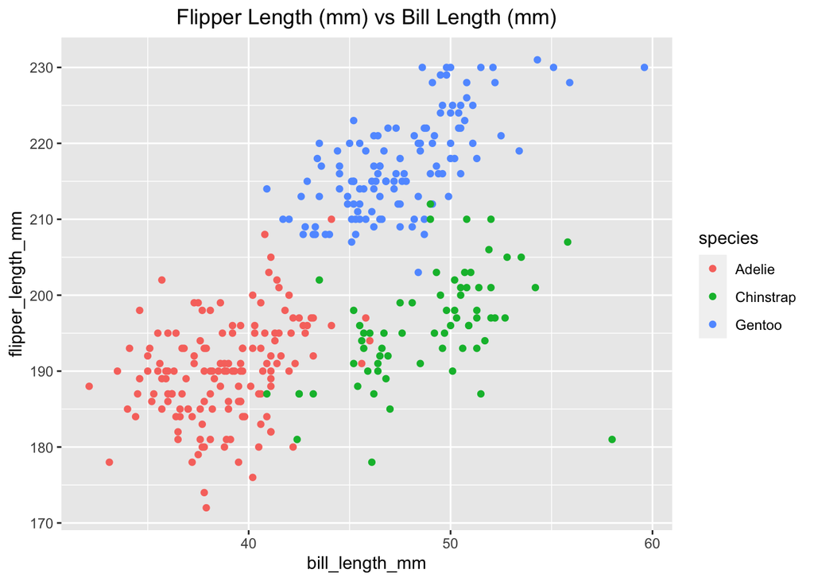

```r
ggplot(penguins, aes(bill_length_mm, flipper_length_mm, colour = species)) + geom_point() + ggtitle("Flipper Length (mm) vs Bill Length (mm)") + theme(plot.title = element_text(hjust = 0.5))
```

```r
ggsave("scatter_plot.pdf", height = 4, width = 6)
```